# Proyecto guerrero de aluminio

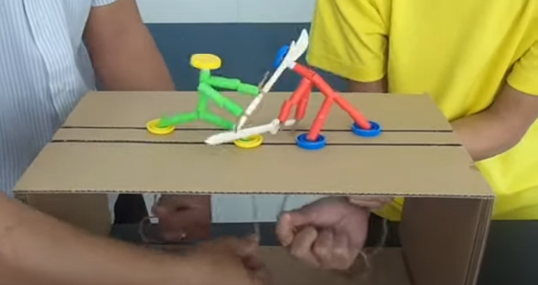

Fuente: Youtube Boy Craft

## Introducción

Como puedes ver en este [video](https://youtu.be/ayIFvxZ25Lk?feature=shared&t=227) los guerreros o fighters pueden ser algo divertido de construir y jugar. La idea es hacer u prototipo y probar como sale.

En la construcción ejercitarás el trabajo en un metal blando como el aluminio con una tolerancias de 1mm.

## Orientaciones para la construcción

- La idea es construir dos prototipos donde cada alumno hace una parte para su equipo.
- En el papel están las piezas numeradas junto con las dimensiones conocidas. El resto se determina en función del material encontrado.
- Este [video](https://www.youtube.com/watch?v=j2tOn6jjmHI) y este [otro](https://www.youtube.com/watch?v=ayIFvxZ25Lk) te pueden orientar en como hacer la cabeza y colocar el hilo
- Las armas del prototipo pueden ser algo simple hasta saber que todo el conjunto funciona bien

## Orientaciones para hacer la plataforma de pelea (ring)

- **Para los que le toque trabajar en esto:** Saca ideas de los videos vistos y haz un boceto con medidas y materiales para proceder a la construcción
- Hay plataformas con una sola ranura y con dos ranuras. Se pueden hacer dos y probar con cual queda mejor.
- No es necesario que sea muy grande, abajo puedes ver, para hacerte una idea, una versión en plástico que es bastante pequeña.

[figure not shown]

Fuente: Pinterest